# Лабораторная работа №13

Архитектура компьютера

## Докладчик

- Володина Алиса Алексеевна
- НКАбд-01-25
- Российский университет дружбы народов им. П. Лумумбы
- 1032253521

## Цель работы

Изучить основы программирования в оболочке ОС UNIX. Научится писать более сложные командные файлы с использованием логических управляющих конструкций и циклов

## Задание

1. Используя команды getopts grep, написать командный файл, который анализирует командную строку с ключами: – -iinputfile — прочитать данные из указанного файла; – -ooutputfile — вывести данные в указанный файл; – -pшаблон — указать шаблон для поиска; – -C — различать большие и малые буквы; – -n — выдавать номера строк. а затем ищет в указанном файле нужные строки, определяемые ключом -p.

## Задание

2. Написать на языке Си программу, которая вводит число и определяет, является ли оно больше нуля, меньше нуля или равно нулю. Затем программа завершается с помощью функции exit(n), передавая информацию в о коде завершения в оболочку. Командный файл должен вызывать эту программу и, проанализировав с помощью команды $?, выдать сообщение о том, какое число было введено.

## Задание

3. Написать командный файл, создающий указанное число файлов, пронумерованных последовательно от 1 до 𝑁 (например 1.tmp, 2.tmp, 3.tmp,4.tmp и т.д.). Число файлов, которые необходимо создать, передаётся в аргументы командной строки. Этот же командный файл должен уметь удалять все созданные им файлы (если они существуют).

## Задание

4. Написать командный файл, который с помощью команды tar запаковывает в архив все файлы в указанной директории. Модифицировать его так, чтобы запаковывались только те файлы, которые были изменены менее недели тому назад (использовать команду find).

## Теоретическое введение

Bash (Bourne Again Shell) — командная оболочка Unix для работы в терминале и автоматизации задач через скрипты. Поддерживается в Linux, Unix и Windows (WSL).

Основные возможности: Обработка простых и сложных команд (конвейер |, перенаправление <, >, >>, условные операторы) Расширенный ввод: автодополнение команд и файлов, история команд Создание и запуск скриптов (последовательности команд с циклами, условиями, функциями)

## Выполнение лабораторной работы

## создадим файл дл первого командного файла и перейдем к редактированию

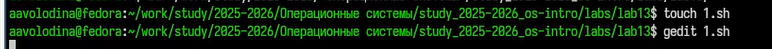

Рисунок 1: создание и редактирование файла

## 1

Используя команды getopts grep, написать командный файл, который анализирует командную строку с ключами: – -iinputfile — прочитать данные из указанного файла; – -ooutputfile — вывести данные в указанный файл; – -pшаблон — указать шаблон для поиска; – -C — различать большие и малые буквы; – -n — выдавать номера строк. а затем ищет в указанном файле нужные строки, определяемые ключом -p. (рис. 2). (рис. 3).

## 1

[figure not shown]

Рисунок 2: первый командный файл

## 1

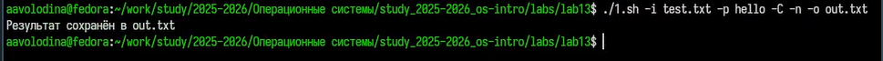

Рисунок 3: работа командного файла

## 2

2. Написать на языке Си программу, которая вводит число и определяет, является ли оно больше нуля, меньше нуля или равно нулю. Затем программа завершается с помощью функции exit(n), передавая информацию в о коде завершения в оболочку. Командный файл должен вызывать эту программу и, проанализировав с помощью команды $?, выдать сообщение о том, какое число было введено.

## 2

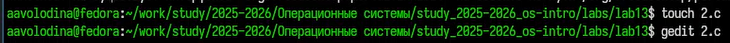

Рисунок 4: создание и редактирование файла 2.c

## 2

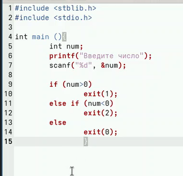

Рисунок 5: код на Си

## 2

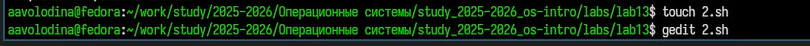

Рисунок 6: создание и редактирование файла 2.sh

## 2

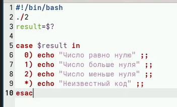

Рисунок 7: код 2 командного файла

## 2

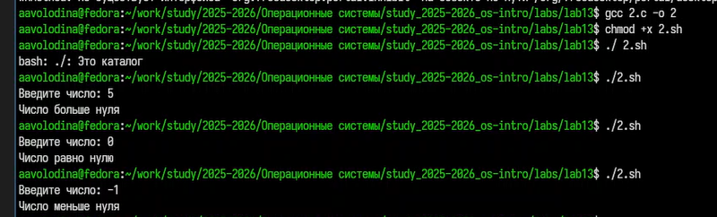

Рисунок 8: работа 2 командного файла

## 3

3. Написать командный файл, создающий указанное число файлов, пронумерованных последовательно от 1 до 𝑁 (например 1.tmp, 2.tmp, 3.tmp,4.tmp и т.д.). Число файлов, которые необходимо создать, передаётся в аргументы командной строки. Этот же командный файл должен уметь удалять все созданные им файлы (если они существуют).

## 3

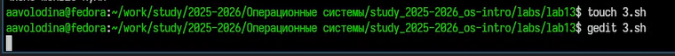

Рисунок 9: создание 3 командного файла

## 3

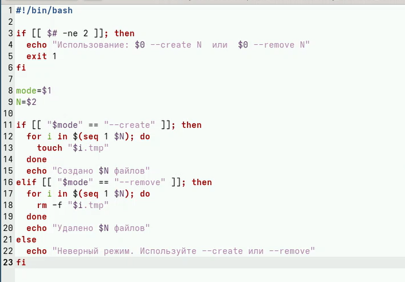

Рисунок 10: код 3 командного файла

## 3

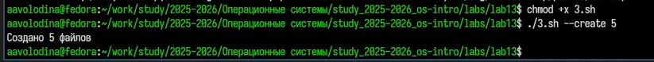

Рисунок 11: работа 3 скрипта(создание файлов)

## 3

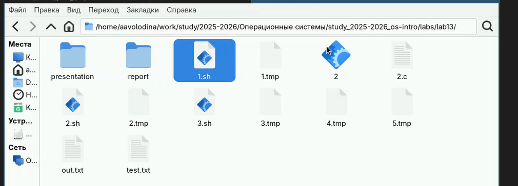

Рисунок 12: проверка созданных файлов

## 3

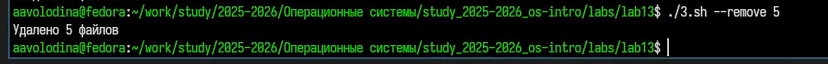

Рисунок 13: работа 3 скрипта(удаление файлов)

## 3

[figure not shown]

Рисунок 14: проверка удаленных файлов

## 4

4. 4. Написать командный файл, который с помощью команды tar запаковывает в архив все файлы в указанной директории. Модифицировать его так, чтобы запаковывались только те файлы, которые были изменены менее недели тому назад (использовать команду find). (рис. 15). (рис. 16).

## 4

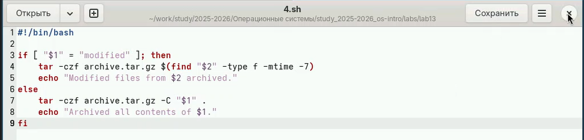

Рисунок 15: код 4 командного файла

## 4

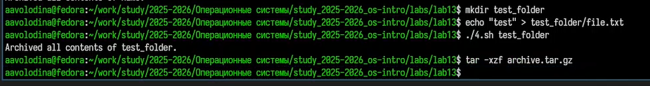

Рисунок 16: работа 4 командного файла

## Выводы

Я изучила основы программирования в оболочке ОС UNIX. Научилась писать более сложные командные файлы с использованием логических управляющих конструкций и циклов

## Контрольные вопросы

1. Предназначение getopts — разбор параметров командной строки в скриптах (например, -a, -f файл), автоматическая обработка флагов и их аргументов.
2. Метасимволы (*, ?, []) используются для генерации имён файлов (шаблонов подстановки) — оболочка заменяет их списком подходящих файлов.
3. Операторы управления действиями: && (И), || (ИЛИ), ; (последовательное выполнение), & (фон), | (конвейер), () (подоболочка), а также , ’, ” для экранирования/группировки.
4. Операторы прерывания цикла: break (выход из цикла), continue (переход к следующей итерации).
5. true всегда возвращает код 0 (успех), false — код 1 (ошибка). Используются для бесконечных циклов, проверки логики и задержек.
6. if test -f man$s/$i.$s проверяет, является ли файл с путём man$s/$i.$s (например, man1/ls.1) обычным файлом (-f).
7. while выполняет цикл, пока условие истинно (код возврата 0), until — пока условие ложно (код возврата не 0). То есть until работает до первого успешного выполнения условия.